--- ---

# What-if Roadmap - Assessing Live Opportunities and their Paths to Success or Failure

Practical walkthroughs on machine learning, data exploration and finding insight.

[figure not shown]

**Resources**

- [YouTube Companion Video](https://www.youtube.com/watch?v=Fu3vKj0EozM&index=1&list=UUq4pm1i_VZqxKVVOz5qRBIA)

In the pursuit of actionable insights, we can use historical closed opportunities that are similar to open ones and analyze what made one win and another lose. This doesn’t necessarily have to be sales data, it can be anything that hasn’t reached some outcome or end point - where there is still some unknown factor.

We’ll use the built-in data set supplied with the C5.0 R library, called Customer Churn. As the name implies, the data contains customer information and usage records from a phone company including whether the customer churned or not. Here is one of the “what ifs”, lack of voice mail usage may indicate a churning customer.

[figure not shown]

The R statistical programming language has a function called **stringdist** which:

> ‘Implements an approximate string matching version of R’s native ’match’ function’.

It contains a large set of [matching approaches](https://cran.r-project.org/web/packages/stringdist/stringdist.pdf):

- **osa** Optimal string aligment, (restricted Damerau-Levenshtein distance)
- **lv** Levenshtein distance
- **dl** Full Damerau-Levenshtein distance
- **hamming** Hamming distance
- **lcs** Longest common substring distance
- **qgram** q-gram distance
- **cosine** cosine distance between q-gram profiles
- **jaccard** Jaccard distance between q-gram profiles
- **jw** Jaro, or Jaro-Winker distance
- **soundex** Distance based on soundex encoding

In this example we are using the **jaccard** matching approach.  
**An Example using a Toy Dataset**

```r
# install.packages('dplyr')
library(dplyr)
# install.packages('C50')
library(C50)

data(churn)

churn_data <- churnTrain
outcome_name <- 'churn'
```

In our toy example, we take the first row as our hypothetical live case, and consider all other rows as closed, historical opportunities (in this case whether or not a customer has churned)

```r
# pick focus customer - from which to find matching cases from your historical data
live_row <- churn_data[1,]
historical_df <- churn_data[-1,]
```

Now that we have two data sets, we apply the stringdist function to get our distance metrics from our historical data in comparison to our picked hypothetical live customer.

```r
# install.packages('stringdist')
library(stringdist)
# hide outcome variable as it is unknown in a live set
similar_metrics <- Reduce(`+`,Map(stringdist, dplyr::select(historical_df, -churn),
                                      dplyr::select(live_row, -churn),
                                      method='jaccard'))

head(similar_metrics)
```

```
## [1]  9.166667 13.911905 15.102381 12.379762 14.668723 12.484199
```

A good next step is to add our distance metrics back to the historical data set and pull the closest matches with our focus row for both positive and negative outcomes.

```r
# print focus row for comparaisoin
live_row
```

```
##   state account_length     area_code international_plan voice_mail_plan
## 1    KS            128 area_code_415                 no             yes
##   number_vmail_messages total_day_minutes total_day_calls total_day_charge
## 1                    25             265.1             110            45.07
##   total_eve_minutes total_eve_calls total_eve_charge total_night_minutes
## 1             197.4              99            16.78               244.7
##   total_night_calls total_night_charge total_intl_minutes total_intl_calls
## 1                91              11.01                 10                3
##   total_intl_charge number_customer_service_calls churn
## 1               2.7                             1    no
```

```r
# assign metrics back to historical data set
historical_df$similar <- similar_metrics

# set number of similar rows needed per outcome
rows_to_collect <- 1
# get first similar item that has positive outcome
historical_df %>% dplyr::filter(churn == 'yes') %>%
  dplyr::arrange(similar) %>% head(rows_to_collect)
```

```
##   state account_length     area_code international_plan voice_mail_plan
## 1    KS            170 area_code_415                 no             yes
##   number_vmail_messages total_day_minutes total_day_calls total_day_charge
## 1                    42             199.5             119            33.92
##   total_eve_minutes total_eve_calls total_eve_charge total_night_minutes
## 1               135              90            11.48               184.6
##   total_night_calls total_night_charge total_intl_minutes total_intl_calls
## 1                49               8.31               10.9                3
##   total_intl_charge number_customer_service_calls churn  similar
## 1              2.94                             4   yes 9.446429
```

```r
# get first similar item that has negative outcome
historical_df %>% dplyr::filter(churn == 'no') %>%
  dplyr::arrange(similar) %>% head(rows_to_collect)
```

```
##   state account_length     area_code international_plan voice_mail_plan
## 1    AR             89 area_code_415                 no             yes
##   number_vmail_messages total_day_minutes total_day_calls total_day_charge
## 1                    25             215.1             140            36.57
##   total_eve_minutes total_eve_calls total_eve_charge total_night_minutes
## 1             197.4              69            16.78               162.1
##   total_night_calls total_night_charge total_intl_minutes total_intl_calls
## 1               117               7.29               10.6               10
##   total_intl_charge number_customer_service_calls churn  similar
## 1              2.86                             1    no 7.621429
```

As we are after insights that are ‘actionable’, we need to look at our features and remove those that don’t lend itself to ‘action’, like geographic markers. Let’s remove ‘State’ and ‘Area Code’.

```r
# state and area_code not of big interest in terms of affectable actions
live_row %>% dplyr::select(-state, -area_code) -> live_row
historical_df %>% dplyr::select(-state, -area_code) -> historical_df


historical_df$similar <- Reduce(`+`,Map(stringdist, dplyr::select(historical_df, -churn),
                                        dplyr::select(live_row, -churn),
                                        method='jaccard'))
# set number of similar rows needed per outcome
rows_to_collect <- 3
# get first similar item that has positive outcome
historical_df %>% dplyr::filter(churn == 'yes') %>%
  dplyr::select(-churn) %>%
  dplyr::arrange(similar) %>% head(rows_to_collect) -> positive_historical_df

# get first similar item that has negative outcome
historical_df %>% dplyr::filter(churn == 'no') %>%
  dplyr::select(-churn) %>%
  dplyr::arrange(similar) %>% head(rows_to_collect) -> negative_historical_df
```

**Correlations - Finding Features Moving in Opposite Direction**

We’re almost there, now that we have our closest top positive and negative similar cases, let’s take a look at what features were the most inverslely correlated. We’ll use the **cor** function to find the features moving in opposite direciton as these may offer insight into what can be done to understand and affect a positive outcome.

```
## [1] "number_vmail_messages"
```

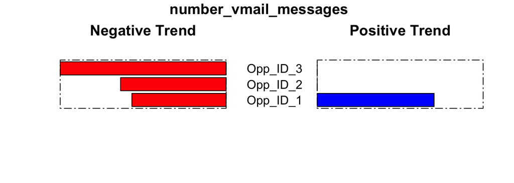

```
## [1] "total_day_minutes"
```

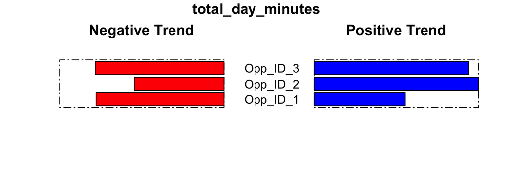

```
## [1] "total_day_charge"
```

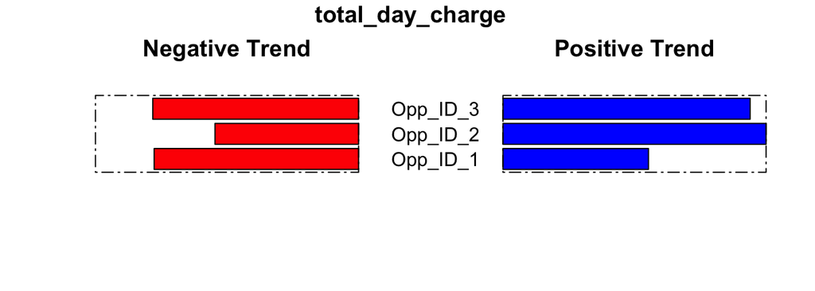

```
## [1] "total_eve_minutes"
```

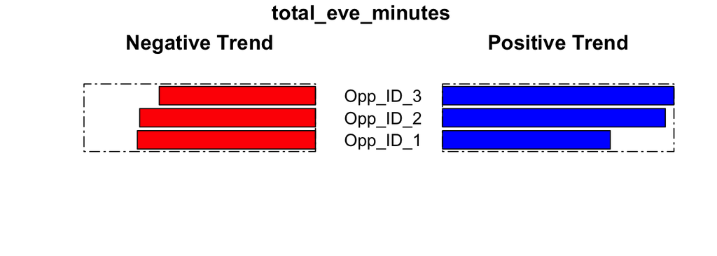

```
## [1] "total_eve_charge"
```

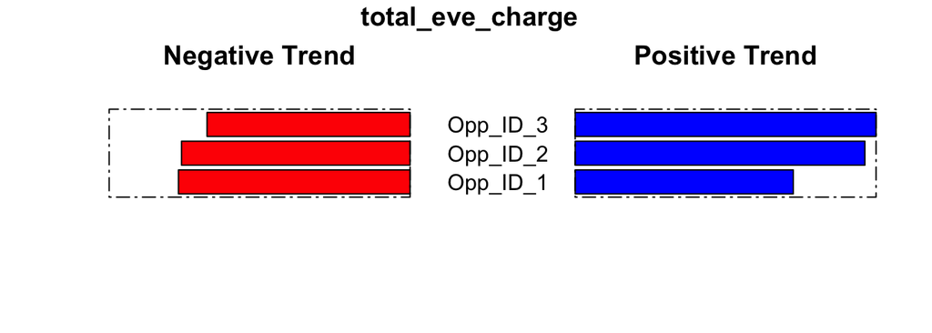

```
## [1] "total_intl_calls"
```

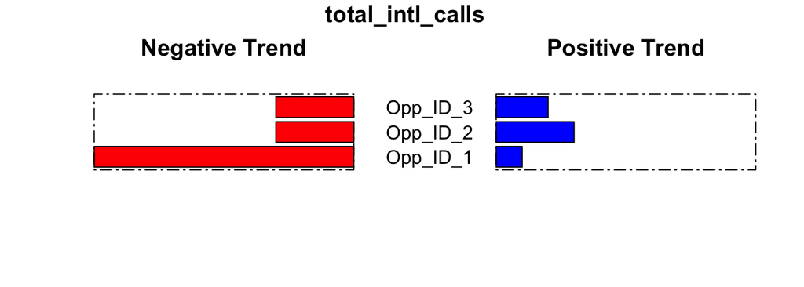

```r
# find extreme examples best portraying different directions ----------------------------
diverging_features <- c()
order_ids <- c()
average_neg <- c()
average_pos <- c()
for (col_id in seq(ncol(positive_historical_df))) {

  positive_historical_df[,col_id]  <- as.numeric(positive_historical_df[,col_id])
  negative_historical_df[,col_id]  <- as.numeric(negative_historical_df[,col_id])

  similar_cor <- (cor(positive_historical_df[,col_id], negative_historical_df[,col_id]))
  if (!is.na(similar_cor) && (similar_cor < -0.2)) {
    print(names(positive_historical_df)[col_id])
    diverging_features <- c(diverging_features, names(positive_historical_df)[col_id])
    order_ids <- c(order_ids, col_id)


    # plot as vertical bar chart
    pos_df <- data.frame('Opp_ID'=paste0('Opp_ID_',seq(nrow(positive_historical_df))),
                         'Value'=(positive_historical_df[,col_id]),
                         'Influence'='Positive')
    neg_df <-  data.frame('Opp_ID'=paste0('Opp_ID_',seq(nrow(negative_historical_df))),
                          'Value'=(negative_historical_df[,col_id]),
                          'Influence'='Negative')

    # flip negative scale for side-by-side plotting
    pos_df$Value <- as.numeric(pos_df$Value)
    neg_df$Value <- as.numeric(neg_df$Value) * -1


    par(mfrow=c(1,2))
    max_xlim <- max(max(abs(neg_df$Value)), max(abs(pos_df$Value)))
    barplot(neg_df$Value, main="Negative Trend", horiz=TRUE, xlim=c((max_xlim * -1),0),
            col='red', border = 1, xaxt='n')
    box(lty = '1373', col = 'black')
    barplot(pos_df$Value, main="Positive Trend", horiz=TRUE, xlim=c(0, max_xlim), col='blue',
            beside=FALSE, names.arg=pos_df$Opp_ID,las=1, xaxt='n')
    box(lty = '1373', col = 'black')
    title(paste("Doctor Trending\n",names(positive_historical_df)[col_id]), outer=TRUE)

    # return conclusion for opportunity ID
    average_neg <- c(average_neg, mean(abs(neg_df$Value)))
    average_pos <- c(average_pos, mean(abs(pos_df$Value)))

  }
}
```

As with most ‘advanced analytics’ results aren’t simple and/or easy - otherwise it would be considered simple and your client would most likely already know about it. It is critical to look at the whole picture, look for outliers and significance, etc.

```
## [1] 1
```

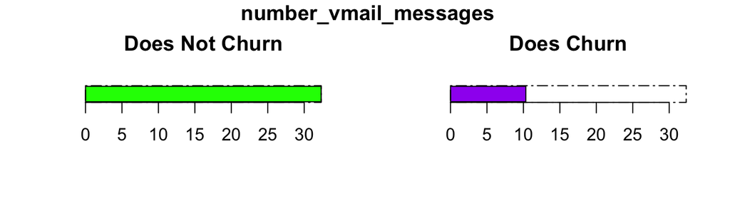

```
## [1] 2
```

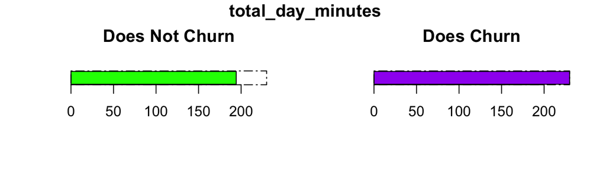

```
## [1] 3
```

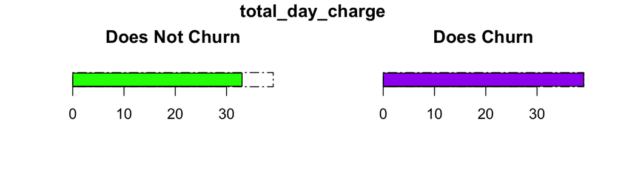

```
## [1] 4
```

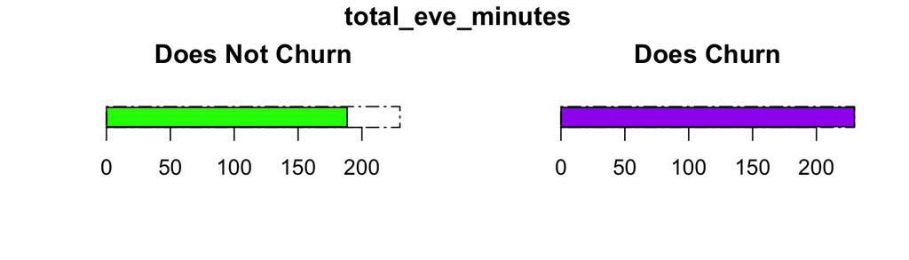

```
## [1] 5
```

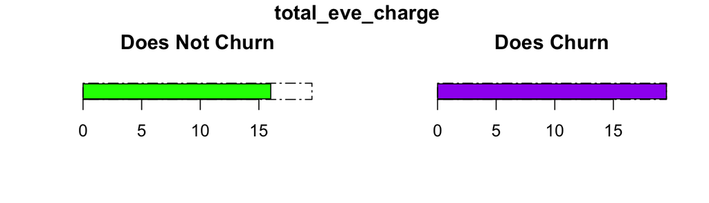

```
## [1] 6
```

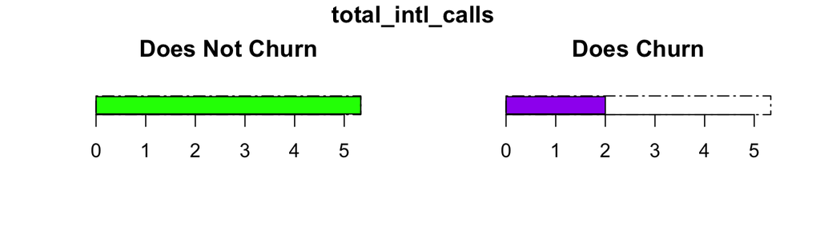

```r
recommendations <-  data.frame(diverging_features = diverging_features,
                               order_ids = order_ids,
                               average_neg = average_neg,
                               average_pos = average_pos)

# present cases of interest
for (case_id in seq(nrow(recommendations))) {
  print(case_id)

  # what if both values are negatigve, or one of each?

  par(mfrow=c(1,2))
  max_xlim <- max(max(abs(recommendations$average_pos[case_id])), max(abs(recommendations$average_neg[case_id])))
  barplot(recommendations$average_neg[case_id], main="Does Not Churn", horiz=TRUE, xlim=c(0, max_xlim),
          col='green', border = 1)
  box(lty = '1373', col = 'black')

  barplot(recommendations$average_pos[case_id], main="Does Churn", horiz=TRUE, xlim=c(0, max_xlim), col='purple',
          beside=FALSE) #, names.arg=recommendations$diverging_features[case_id],las=1)

  box(lty = '1373', col = 'black')
  title(paste("Doctor Trending\n",recommendations$diverging_features[case_id]), outer=TRUE)

}
```

Manuel Amunategui - Follow me on Twitter: @amunategui

**Thanks again for the artwork, Lucas!!**